# 03_missing_values

## 目的

- Uniswap v3 サブグラフの TVL が負値や欠損値を含む原因を把握し、データ品質改善策を検討する。

## 仮説

1. TVL の負値・欠損は特定の時間帯（例：深夜帯）やイベント（Collect／Mint の未処理）に集中している。
2. 欠損日の分布は API サーバーのダウンタイムやオンチェーンイベント頻度に対応している。
3. プール属性（手数料帯・トークンペア）ごとに欠損・負値発生率に差がある。

```python
# パッケージをインストール
%pip install -qe ..
```

```python
import duckdb
import japanize_matplotlib  # noqa: F401
import matplotlib.pyplot as plt
import numpy as np
import pandas as pd
import seaborn as sns

from statsmodels.tsa.seasonal import STL
```

## 基本設定

```python
plt.style.use("ggplot")
```

```python
with duckdb.connect("../data/raw/etl_from_sf.duckdb", read_only=True) as con:
    df = con.execute("SELECT * FROM raw_clean_with_pool").df()
df.head()
```

|  | hour_ts | id | volume_usd | tvl_usd | liquidity | volume_token0 | volume_token1 | fees_usd | open_price | high_price | ... | load_ts | fee_tier | token0_id | token0_symbol | token0_name | token0_decimals | token1_id | token1_symbol | token1_name | token1_decimals |
| --- | --- | --- | --- | --- | --- | --- | --- | --- | --- | --- | --- | --- | --- | --- | --- | --- | --- | --- | --- | --- | --- |
| 0 | 1746784800 | 0xac8ba9d6fa2f9ff7c712bef5670cb0f7e4177965-485218 | 698.000000 | 2.711293e+05 | 3.112152e+17 | 6346.977788 | 698.000000 | 2.094000 | 9.059070 | 9.059070 | ... | 2025-05-09 11:00:09.148000+00:00 | 3000 | 0x2d8ea194902bc55431420bd26be92b0782dce91d | ZND | ZNDToken | 18 | 0xdac17f958d2ee523a2206206994597c13d831ec7 | USDT | Tether USD | 6 |
| 1 | 1745672400 | 0xfa6e8e97ececdc36302eca534f63439b1e79487b-484909 | 302.294707 | 5.368977e+04 | 2.713280e+13 | 302.346914 | 302.242500 | 0.030229 | 1.000449 | 1.000449 | ... | 2025-05-09 11:00:22.403000+00:00 | 100 | 0xa0b86991c6218b36c1d19d4a2e9eb0ce3606eb48 | USDC | USD Coin | 6 | 0xdac17f958d2ee523a2206206994597c13d831ec7 | USDT | Tether USD | 6 |
| 2 | 1745672400 | 0x7ce04536279a74951c1a0148b5488d8a027a9bf8-484909 | 6.605206 | 2.190198e+02 | 4.443265e+19 | 82.062242 | 0.003694 | 0.066052 | 22165.049401 | 22165.049401 | ... | 2025-05-09 11:00:22.403000+00:00 | 10000 | 0x419c4db4b9e25d6db2ad9691ccb832c8d9fda05e | DRGN | Dragon | 18 | 0xc02aaa39b223fe8d0a0e5c4f27ead9083c756cc2 | WETH | Wrapped Ether | 18 |
| 3 | 1744063200 | 0x0598690ad1daffc3ac47fd6adcaeac547c067e26-484462 | 0.000000 | 3.658733e+06 | 7.049047e+26 | 0.000000 | 0.000000 | 0.000000 | 1.007475 | 1.007475 | ... | 2025-05-09 11:51:11.735000+00:00 | 3000 | 0x57e114b691db790c35207b2e685d4a43181e6061 | ENA | ENA | 18 | 0x8be3460a480c80728a8c4d7a5d5303c85ba7b3b9 | sENA | Staked ENA | 18 |
| 4 | 1744063200 | 0x6288694eb218614a27777f2b52d3f8d4819233c0-484462 | 1697.111986 | 3.920453e+03 | 6.054509e+20 | 79772.446480 | 1.080806 | 16.971120 | 78952.973584 | 81377.447456 | ... | 2025-05-09 11:51:11.735000+00:00 | 10000 | 0xb1d1eae60eea9525032a6dcb4c1ce336a1de71be | DRV | Derive | 18 | 0xc02aaa39b223fe8d0a0e5c4f27ead9083c756cc2 | WETH | Wrapped Ether | 18 |

5 rows × 28 columns

```python
raw_clean_with_pool = df
```

```python
df.shape[0]
```

```
134736
```

```python
df[["token0_symbol", "token1_symbol"]].drop_duplicates().shape[0]
```

```
3526
```

```python
(df["tvl_usd"] < 0).mean()
```

```
2.2265764161026006e-05
```

### データ概要サマリー

| 指標 | 値 |
| --- | --- |
| 総行数 | 134736 行 |
| 期間 | 2025-03-04 22:00:00 〜 2025-05-10 05:00:00` |
| ユニークプール数 | 4115 件 |
| トークンペア数 | 3526 種類 |
| 欠損率 (`tvl_usd`) | 0 |
| 負値率 (`tvl_usd`) | 2.2265764161026006e-05 |

**結論**

- データは **約 13.5 万行**、**2025-03-04 22:00 〜 2025-05-10 05:00** の約 2 ヶ月分
- プールは **4,115 件**、トークンペアは **3,526 種類**
- TVL の **欠損率 0%**、**負値率 約 0.00223%**（約 3 件／全 134,736 行、モデル学習前に要対応）

## 基本的なデータ変換

```python
# タイムスタンプを日時に変換
raw_clean_with_pool["datetime"] = pd.to_datetime(raw_clean_with_pool["hour_ts"], unit="s")
```

```python
# IDからプールアドレスとインデックスを抽出
raw_clean_with_pool["pool_address"] = raw_clean_with_pool["id"].str.split("-").str[0]
raw_clean_with_pool["block_index"] = raw_clean_with_pool["id"].str.split("-").str[1]
```

```python
# fee tier ごとのプール数
fee_tier_counts = raw_clean_with_pool["fee_tier"].value_counts().reset_index()
fee_tier_counts.columns = ["fee_tier", "count"]
fee_tier_counts
```

|  | fee_tier | count |
| --- | --- | --- |
| 0 | 3000 | 58274 |
| 1 | 10000 | 56493 |
| 2 | 500 | 11302 |
| 3 | 100 | 8667 |

## プールごとのデータについて調査

```python
raw_clean_with_pool.head()
```

|  | hour_ts | id | volume_usd | tvl_usd | liquidity | volume_token0 | volume_token1 | fees_usd | open_price | high_price | ... | token0_symbol | token0_name | token0_decimals | token1_id | token1_symbol | token1_name | token1_decimals | datetime | pool_address | block_index |
| --- | --- | --- | --- | --- | --- | --- | --- | --- | --- | --- | --- | --- | --- | --- | --- | --- | --- | --- | --- | --- | --- |
| 0 | 1746784800 | 0xac8ba9d6fa2f9ff7c712bef5670cb0f7e4177965-485218 | 698.000000 | 2.711293e+05 | 3.112152e+17 | 6346.977788 | 698.000000 | 2.094000 | 9.059070 | 9.059070 | ... | ZND | ZNDToken | 18 | 0xdac17f958d2ee523a2206206994597c13d831ec7 | USDT | Tether USD | 6 | 2025-05-09 10:00:00 | 0xac8ba9d6fa2f9ff7c712bef5670cb0f7e4177965 | 485218 |
| 1 | 1745672400 | 0xfa6e8e97ececdc36302eca534f63439b1e79487b-484909 | 302.294707 | 5.368977e+04 | 2.713280e+13 | 302.346914 | 302.242500 | 0.030229 | 1.000449 | 1.000449 | ... | USDC | USD Coin | 6 | 0xdac17f958d2ee523a2206206994597c13d831ec7 | USDT | Tether USD | 6 | 2025-04-26 13:00:00 | 0xfa6e8e97ececdc36302eca534f63439b1e79487b | 484909 |
| 2 | 1745672400 | 0x7ce04536279a74951c1a0148b5488d8a027a9bf8-484909 | 6.605206 | 2.190198e+02 | 4.443265e+19 | 82.062242 | 0.003694 | 0.066052 | 22165.049401 | 22165.049401 | ... | DRGN | Dragon | 18 | 0xc02aaa39b223fe8d0a0e5c4f27ead9083c756cc2 | WETH | Wrapped Ether | 18 | 2025-04-26 13:00:00 | 0x7ce04536279a74951c1a0148b5488d8a027a9bf8 | 484909 |
| 3 | 1744063200 | 0x0598690ad1daffc3ac47fd6adcaeac547c067e26-484462 | 0.000000 | 3.658733e+06 | 7.049047e+26 | 0.000000 | 0.000000 | 0.000000 | 1.007475 | 1.007475 | ... | ENA | ENA | 18 | 0x8be3460a480c80728a8c4d7a5d5303c85ba7b3b9 | sENA | Staked ENA | 18 | 2025-04-07 22:00:00 | 0x0598690ad1daffc3ac47fd6adcaeac547c067e26 | 484462 |
| 4 | 1744063200 | 0x6288694eb218614a27777f2b52d3f8d4819233c0-484462 | 1697.111986 | 3.920453e+03 | 6.054509e+20 | 79772.446480 | 1.080806 | 16.971120 | 78952.973584 | 81377.447456 | ... | DRV | Derive | 18 | 0xc02aaa39b223fe8d0a0e5c4f27ead9083c756cc2 | WETH | Wrapped Ether | 18 | 2025-04-07 22:00:00 | 0x6288694eb218614a27777f2b52d3f8d4819233c0 | 484462 |

5 rows × 31 columns

```python
# すべてのプール（負値を持つプールも持たないプールも含む）をリストアップ
all_pools = raw_clean_with_pool["pool_address"].unique()
print(f"プールの総数: {len(all_pools)}")

# 各プールごとの統計情報
all_pool_stats = (
    raw_clean_with_pool.groupby("pool_address")
    .agg(
        {
            "tvl_usd": [
                ("データ件数", "count"),
                ("負値件数", lambda x: (x < 0).sum()),
                ("負値割合", lambda x: (x < 0).sum() / len(x) if len(x) > 0 else 0),
                ("最小値", "min"),
                ("最大値", "max"),
                ("平均値", "mean"),
            ]
        }
    )
    .reset_index()
)

# 多階層カラムをフラット化
all_pool_stats.columns = ["_".join(col).strip("_") for col in all_pool_stats.columns.values]

# 負値割合でソート
sorted_pools = all_pool_stats.sort_values("tvl_usd_負値割合", ascending=False)
```

```
プールの総数: 4115
```

```python
print("負値を持つプール（負値割合が高い順）:")
sorted_pools[sorted_pools["tvl_usd_負値割合"] > 0].tail(20)
sorted_pools[sorted_pools["tvl_usd_負値割合"] > 0].describe()
```

```
負値を持つプール（負値割合が高い順）:
```

|  | tvl_usd_データ件数 | tvl_usd_負値件数 | tvl_usd_負値割合 | tvl_usd_最小値 | tvl_usd_最大値 | tvl_usd_平均値 |
| --- | --- | --- | --- | --- | --- | --- |
| count | 2.000000 | 2.000000 | 2.000000 | 2.000000 | 2.000000e+00 | 2.000000e+00 |
| mean | 83.500000 | 1.500000 | 0.056369 | -58454.661219 | 1.513954e+07 | 6.574027e+05 |
| std | 103.944697 | 0.707107 | 0.061703 | 76121.202435 | 2.139165e+07 | 9.163381e+05 |
| min | 10.000000 | 1.000000 | 0.012739 | -112280.479652 | 1.335739e+04 | 9.453872e+03 |
| 25% | 46.750000 | 1.250000 | 0.034554 | -85367.570435 | 7.576447e+06 | 3.334283e+05 |
| 50% | 83.500000 | 1.500000 | 0.056369 | -58454.661219 | 1.513954e+07 | 6.574027e+05 |
| 75% | 120.250000 | 1.750000 | 0.078185 | -31541.752002 | 2.270263e+07 | 9.813772e+05 |
| max | 157.000000 | 2.000000 | 0.100000 | -4628.842785 | 3.026571e+07 | 1.305352e+06 |

```python
print("負値がないプール最初の10件:")
sorted_pools[sorted_pools["tvl_usd_負値割合"] == 0]
```

```
負値がないプール最初の10件:
```

|  | pool_address | tvl_usd_データ件数 | tvl_usd_負値件数 | tvl_usd_負値割合 | tvl_usd_最小値 | tvl_usd_最大値 | tvl_usd_平均値 |
| --- | --- | --- | --- | --- | --- | --- | --- |
| 0 | 0x0002e63328169d7feea121f1e32e4f620abf0352 | 6 | 0 | 0.0 | 25713.509079 | 38845.701455 | 33338.319679 |
| 2748 | 0xab7b43183d2ed9de4ced6abd040b1b362601888a | 1 | 0 | 0.0 | 8.799298 | 8.799298 | 8.799298 |
| 2736 | 0xaa6e758afdb93822bd04b10b4f5a3eb54db6467e | 22 | 0 | 0.0 | 281.884946 | 744.182528 | 552.626165 |
| 2737 | 0xaab00afb2ee835d7065f66eba3c000a7e7a82b67 | 2 | 0 | 0.0 | 806.600583 | 809.611764 | 808.106174 |
| 2738 | 0xaac4f2193011aa80c4549e92feb68aaf647e82cc | 10 | 0 | 0.0 | 64868.401721 | 92277.006812 | 80591.283784 |
| ... | ... | ... | ... | ... | ... | ... | ... |
| 1377 | 0x570319b1b6330e09ec0b64ac0c51fef3d64dbe0e | 7 | 0 | 0.0 | 639.200020 | 1433.529569 | 1255.201593 |
| 1378 | 0x571464618a1f7b80d9d56a4b805432bc825ad604 | 3 | 0 | 0.0 | 483209.326773 | 623586.629736 | 532726.674470 |
| 1379 | 0x5720eb958685deeeb5aa0b34f677861ce3a8c7f5 | 37 | 0 | 0.0 | 86392.367044 | 86629.644313 | 86474.226915 |
| 1380 | 0x57213ea46aef7940193a27f0cd1e1062b17268c5 | 4 | 0 | 0.0 | 43.530703 | 3286.355120 | 1899.223742 |
| 4114 | 0xffe91de50e87b19a622b15adfc9a8589c9532b8c | 10 | 0 | 0.0 | 167.889075 | 263.332660 | 213.823621 |

4113 rows × 7 columns

```python
# 負値プールと非負値プールの数を確認
negative_pools = sorted_pools[sorted_pools["tvl_usd_負値割合"] > 0]
valid_pools = sorted_pools[sorted_pools["tvl_usd_負値割合"] == 0]
print(f"負値を持つプール数: {len(negative_pools)} ({len(negative_pools) / len(all_pools):.2%})")
print(f"負値のないプール数: {len(valid_pools)} ({len(valid_pools) / len(all_pools):.2%})")
```

```
負値を持つプール数: 2 (0.05%)
負値のないプール数: 4113 (99.95%)
```

```python
# 上位TVLプールと負値プールの関係を確認
tvl_sorted = all_pool_stats.sort_values("tvl_usd_平均値", ascending=False)
print("TVL上位プール:")
tvl_sorted.head(10)[["pool_address", "tvl_usd_データ件数", "tvl_usd_負値件数", "tvl_usd_負値割合", "tvl_usd_平均値"]]
```

```
TVL上位プール:
```

|  | pool_address | tvl_usd_データ件数 | tvl_usd_負値件数 | tvl_usd_負値割合 | tvl_usd_平均値 |
| --- | --- | --- | --- | --- | --- |
| 2186 | 0x88e6a0c2ddd26feeb64f039a2c41296fcb3f5640 | 204 | 0 | 0.0 | 3.845482e+08 |
| 2223 | 0x8ad599c3a0ff1de082011efddc58f1908eb6e6d8 | 203 | 0 | 0.0 | 2.752800e+08 |
| 2462 | 0x99ac8ca7087fa4a2a1fb6357269965a2014abc35 | 201 | 0 | 0.0 | 2.444327e+08 |
| 3256 | 0xcbcdf9626bc03e24f779434178a73a0b4bad62ed | 198 | 0 | 0.0 | 2.223835e+08 |
| 1237 | 0x4e68ccd3e89f51c3074ca5072bbac773960dfa36 | 203 | 0 | 0.0 | 1.945938e+08 |
| 1101 | 0x4585fe77225b41b697c938b018e2ac67ac5a20c0 | 204 | 0 | 0.0 | 1.029443e+08 |
| 298 | 0x11b815efb8f581194ae79006d24e0d814b7697f6 | 204 | 0 | 0.0 | 8.842621e+07 |
| 1388 | 0x5777d92f208679db4b9778590fa3cab3ac9e2168 | 203 | 0 | 0.0 | 6.294337e+07 |
| 2522 | 0x9db9e0e53058c89e5b94e29621a205198648425b | 188 | 0 | 0.0 | 6.208514e+07 |
| 2668 | 0xa6cc3c2531fdaa6ae1a3ca84c2855806728693e8 | 203 | 0 | 0.0 | 6.079627e+07 |

```python
# 負値の分析
negative_tvl = raw_clean_with_pool[raw_clean_with_pool["tvl_usd"] < 0]
print(f"負のTVL値の件数: {len(negative_tvl)}")
print(f"負のTVL値を持つユニークなプールID: {negative_tvl['pool_address'].nunique()}")
```

```
負のTVL値の件数: 3
負のTVL値を持つユニークなプールID: 2
```

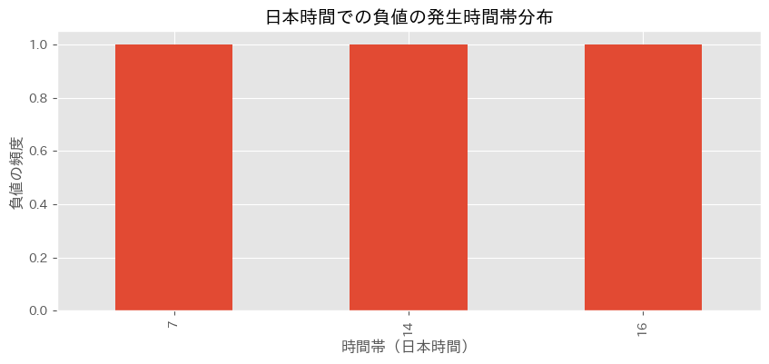

```python
# UTC 時刻を JST に変換
negative_tvl.loc[:, "hour_utc"] = pd.to_datetime(negative_tvl["hour_ts"], unit="s").dt.hour
negative_tvl.loc[:, "hour_jst"] = (negative_tvl["hour_utc"] + 9) % 24

# JST 時間帯ごとの頻度集計とプロット
hourly_pattern_jst = negative_tvl.groupby("hour_jst").size()
plt.figure(figsize=(10, 4))
hourly_pattern_jst.plot(kind="bar")
plt.title("日本時間での負値の発生時間帯分布")
plt.xlabel("時間帯（日本時間）")
plt.ylabel("負値の頻度")
plt.show()
```

図より、

## TVL 負値問題の概要と対応策

Uniswap v3 のサブグラフにおいて、プールごとの TVL（Total Value Locked）が負の値になる既知の不具合です。  
主な要因として以下が報告されています。

### 原因

1. **Collect イベントの未反映**  
   流動性プロバイダーが手数料を徴収する際の Collect イベントでのトークン差し引きが正しく処理されず、負の値が発生する。
2. **手数料の累積誤差**  
   サブグラフがスワップ時の手数料（0.01%～ 1%）を TVL に反映しないため、実際の残高との差分が発生し、負値となるケースがある。
3. **イベント処理の不整合**  
   Swap/Mint/Burn などの順序を時系列で再現する際、内部トランザクションがログに記録されず、TVL／流動性が負に“潰れる”。

### 影響

- 高取引量プール（例：USDC/ETH 0.05%）で報告値が実値の約 2 倍に膨らむ場合があり、データの信頼性が低下する。
- LP 収益（APR）計算に悪影響を及ぼし、誤った投資判断を誘発する可能性がある。

### 対応策

#### 1. 暫定対応

1. **負の TVL → 欠損値化 (NaN)**

   ```
   df.loc[df['tvl_usd'] < 0, 'tvl_usd'] = np.nan
   ```

   - **目的**：計算エラーをモデルに学習させない
   - **備考**：Mint 起因の一時的マイナスもここで除外
2. **欠損値の補完 (Imputation)**

   ```
   # プールごとの時系列前方・後方補完
   df['tvl_usd'] = df.groupby('pool_address')['tvl_usd'] \
                     .apply(lambda s: s.ffill().bfill())
   ```

   - **目的**：連続性を保ちつつ合理的な値に置き換え
3. **データ品質フラグの付与**

   ```
   df['tvl_error'] = df['tvl_usd'].isna().astype(int)
   ```

   - **目的**：後続モデルで「どこが補完されたか」を特徴量として利用

### 今後の改善検討事項

1. **イベント別エラー切り分け**
   - Mint／Burn／Collect の各イベント原因を識別し、Mint 起因の一時的な負値にはペナルティを与えない
   - Uncollected Fees や Collect イベントのみをエラー扱いするロジックの実装
2. **オンチェーン直接取得**
   - Etherscan 等で `balanceOf(poolAddress)` を呼び出して token0/token1 残高を取得
   - 最も正確な TVL 計算が可能
3. **代替分析プラットフォームの活用**
   - Dune Analytics の公式ダッシュボードを確認する
   - Flipside Crypto で独自 SQL を実行
4. **公式アップデートの注視**
   - Uniswap Governance フォーラム
   - The Graph ステータスページ

### 参考リンク

- [Uniswap v3 サブグラフ Issue #74](https://github.com/Uniswap/v3-subgraph/issues/74)

## データの欠損値を確認

```python
from datetime import datetime

import pandas as pd

daily = (
    raw_clean_with_pool.assign(date=lambda df: df["datetime"].dt.date).groupby("date")["volume_usd"].sum().reset_index()
)

# 日付を適切に変換
start_date = pd.to_datetime("2025-03-05").date()
end_date = pd.to_datetime("2025-05-05").date()
# 日付のみの欠損をチェック
if isinstance(daily["date"].iloc[0], datetime):
    daily_dates = set(d.date() for d in daily["date"])
else:
    daily_dates = set(daily["date"])
# 期間内のすべての日付を生成
all_dates = pd.date_range(start=start_date, end=end_date).date
missing_dates = [d for d in all_dates if d not in daily_dates]
print("欠損している日付:")
for d in missing_dates:
    print(f"{d}")
# 元データから時間単位の欠損をチェック
print("\n時間単位の詳細:")
# datetimeの一覧を取得（元データから）
if "datetime" in raw_clean_with_pool.columns:
    # ユニークな日時を取得
    unique_timestamps = raw_clean_with_pool["datetime"].sort_values().unique()
    # 期間内のみをフィルタリング
    period_timestamps = [ts for ts in unique_timestamps if start_date <= ts.date() <= end_date]
    # 日付ごとの時間をまとめる
    date_hours = {}
    for ts in period_timestamps:
        date = ts.date()
        hour = ts.hour
        if date not in date_hours:
            date_hours[date] = []
        date_hours[date].append(hour)
    # 各日付の存在する時間を表示（欠損がある場合のみ）
    for date in sorted(date_hours.keys()):
        hours = sorted(date_hours[date])
        missing_hours = [h for h in range(24) if h not in hours]
        # 欠損がある場合のみ表示
        if missing_hours:
            print(f"{date}: データあり: {hours}, 欠損: {missing_hours}")
    # データがまったくない日付を表示
    complete_missing_dates = [d for d in missing_dates if d not in date_hours]
    if complete_missing_dates:
        print("\n完全に欠損している日付:")
        for d in complete_missing_dates:
            print(f"{d}: すべての時間帯でデータなし")
else:
    print("元データに datetime 列がありません")
```

```
欠損している日付:
2025-03-28
2025-03-29
2025-03-30
2025-03-31
2025-04-01
2025-04-02

時間単位の詳細:
2025-03-21: データあり: [0, 1, 2, 4, 5, 6, 7, 8, 9, 10, 11, 12, 13, 14, 15, 16, 17, 18, 19, 20, 21, 22, 23], 欠損: [3]
2025-03-27: データあり: [0, 1, 2, 3, 4, 5, 6, 7, 8, 9, 10, 11, 12, 13, 14, 15, 16, 17, 18, 19, 21], 欠損: [20, 22, 23]
2025-04-03: データあり: [23], 欠損: [0, 1, 2, 3, 4, 5, 6, 7, 8, 9, 10, 11, 12, 13, 14, 15, 16, 17, 18, 19, 20, 21, 22]
2025-04-04: データあり: [0, 1, 2, 3, 4, 5, 6, 7, 8, 9, 10, 11, 12, 13, 14, 15, 16, 17, 18, 19, 20, 21], 欠損: [22, 23]
2025-04-17: データあり: [0, 1, 2, 3, 4, 5, 6, 7, 8, 9, 10, 11, 12, 13, 14, 15, 16, 17, 18, 19, 20, 21], 欠損: [22, 23]
2025-04-18: データあり: [5, 6, 7, 8, 9, 10, 11, 12, 13, 14, 15, 16, 17, 19, 20, 21, 22, 23], 欠損: [0, 1, 2, 3, 4, 18]
2025-05-05: データあり: [0, 1, 2, 3, 4, 5, 6, 7, 8, 9, 10, 11, 12, 19, 20, 21, 22, 23], 欠損: [13, 14, 15, 16, 17, 18]

完全に欠損している日付:
2025-03-28: すべての時間帯でデータなし
2025-03-29: すべての時間帯でデータなし
2025-03-30: すべての時間帯でデータなし
2025-03-31: すべての時間帯でデータなし
2025-04-01: すべての時間帯でデータなし
2025-04-02: すべての時間帯でデータなし
```

## 時系列特性

1. 日次／週次トレンド分解（STL 分解）
2. 曜日・時間帯ごとの取引量（`volume_usd`）平均プロット
3. TVL 負値発生の時間帯ヒートマップ

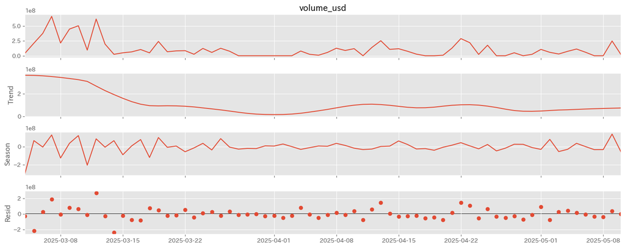

```python
# 日次で集計
daily = df.set_index("datetime")["volume_usd"].resample("D").sum()
res = STL(daily, period=7).fit()

fig = res.plot()
fig.set_size_inches(15, 6)
plt.tight_layout()
plt.show()
```

図より、

- **トレンド (Trend)**
  - 3 月上旬（≈3×10⁸ USD）をピークに中旬以降は急激に減少し、4 月上旬にはほぼゼロに近い水準。その後は緩やかに持ち直し。
- **季節性 (Seasonal)**
  - 7 日サイクルでの上下動が見られるが、振幅は比較的小さく、取引量全体の変動要因としては限定的。
- **残差 (Resid)**
  - 3/8–3/10 や 4/22 周辺に大きなスパイク・ドロップが散在。
  - → 大口スワップやサブグラフのリロードタイミングなど、一過性イベントの影響かもしれません。

## 流動性

```python
# 基本統計量の確認
print("=== liquidity の基本統計 ===")
print(raw_clean_with_pool["liquidity"].describe())
print("\n=== sqrt_price の基本統計 ===")
print(raw_clean_with_pool["sqrt_price"].describe())

# 値の範囲を確認
print(f"\nliquidity の範囲: {raw_clean_with_pool['liquidity'].min()} から {raw_clean_with_pool['liquidity'].max()}")
print(f"sqrt_price の範囲: {raw_clean_with_pool['sqrt_price'].min()} から {raw_clean_with_pool['sqrt_price'].max()}")

# 科学的表記法でスケールを把握
print(f"\nliquidity の最大値 (科学的表記): {raw_clean_with_pool['liquidity'].max():.2e}")
print(f"sqrt_price の最大値 (科学的表記): {raw_clean_with_pool['sqrt_price'].max():.2e}")
```

```
=== liquidity の基本統計 ===
count    1.347360e+05
mean     2.937187e+30
std      2.302294e+32
min      0.000000e+00
25%      3.601585e+17
50%      1.181802e+21
75%      3.255444e+22
max      1.833394e+34
Name: liquidity, dtype: float64

=== sqrt_price の基本統計 ===
count    1.347360e+05
mean     3.037088e+44
std      2.106574e+46
min      0.000000e+00
25%      7.285223e+25
50%      1.503591e+27
75%      4.496508e+29
max      1.461447e+48
Name: sqrt_price, dtype: float64

liquidity の範囲: 0.0 から 1.8333944448008398e+34
sqrt_price の範囲: 0.0 から 1.4614467034852102e+48

liquidity の最大値 (科学的表記): 1.83e+34
sqrt_price の最大値 (科学的表記): 1.46e+48
```

## プール属性別分析

- **手数料帯 (`fee_tier`)** ごとの欠損率・負値率
- **トークンペア** 上位 10 種での異常発生頻度

```python
ft = (
    df.assign(is_na=df["tvl_usd"].isna(), is_neg=df["tvl_usd"] < 0)
    .groupby("fee_tier")[["is_na", "is_neg"]]
    .mean()
    .reset_index()
)
display(ft)
```

|  | fee_tier | is_na | is_neg |
| --- | --- | --- | --- |
| 0 | 100 | 0.0 | 0.000000 |
| 1 | 10000 | 0.0 | 0.000000 |
| 2 | 3000 | 0.0 | 0.000017 |
| 3 | 500 | 0.0 | 0.000177 |

## 巨大固定小数点整数について

### 桁数の分布を確認

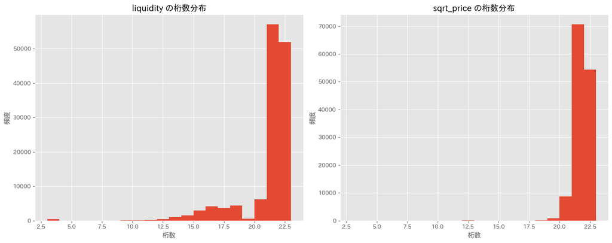

```python
df["liquidity_digits"] = df["liquidity"].astype(str).str.len()
df["sqrt_price_digits"] = df["sqrt_price"].astype(str).str.len()

plt.figure(figsize=(15, 6))

plt.subplot(1, 2, 1)
plt.hist(df["liquidity_digits"], bins=range(min(df["liquidity_digits"]), max(df["liquidity_digits"]) + 2))
plt.title("liquidity の桁数分布")
plt.xlabel("桁数")
plt.ylabel("頻度")

plt.subplot(1, 2, 2)
plt.hist(df["sqrt_price_digits"], bins=range(min(df["sqrt_price_digits"]), max(df["sqrt_price_digits"]) + 2))
plt.title("sqrt_price の桁数分布")
plt.xlabel("桁数")
plt.ylabel("頻度")

plt.tight_layout()
plt.show()
```

### スケーリング係数の選定

- DeFi のスマートコントラクトの慣例からスケーリング係数を推定します。
- 多くの ERC20 トークンでは 10^18 がスケーリング係数（1 Ether = 10^18 Wei）を使用しているため、これを推定スケーリング係数の候補に追加します。

#### スケーリング係数候補について

- **1e6 (10⁶)**
  - USDC や USDT のような「小数点以下 6 桁」精度のトークンに対応
- **1e12 (10¹²)**
  - 一部トークンが「小数点以下 12 桁」を採用するケースを想定
- **1e18 (10¹⁸)**
  - Ether や大多数の ERC-20 トークンが「小数点以下 18 桁」精度で発行
- **2**⁹⁶
  - Uniswap v3 の **Q64.96** 固定小数点表現（`sqrt_price` や `tick` 計算）で使用
- **2**¹²⁸
  - 固定小数点を格納する最大ビット幅としての上限候補（Ethereum の 256 ビットワードに対してビット幅余裕をみた想定）

```python
# 可能なスケーリング係数のリスト
scaling_factors = [1e6, 1e12, 1e18, 2**96, 2**128]

# 各スケーリング係数でデータを変換したときの統計を確認
for factor in scaling_factors:
    print(f"\n=== スケーリング係数: {factor:.2e} ===")
    print(f"liquidity / {factor:.2e}:")
    print(df["liquidity"].divide(factor).describe())
    print(f"\nsqrt_price / {factor:.2e}:")
    print(df["sqrt_price"].divide(factor).describe())
```

```
=== スケーリング係数: 1.00e+06 ===
liquidity / 1.00e+06:
count    1.347360e+05
mean     2.937187e+24
std      2.302294e+26
min      0.000000e+00
25%      3.601585e+11
50%      1.181802e+15
75%      3.255444e+16
max      1.833394e+28
Name: liquidity, dtype: float64

sqrt_price / 1.00e+06:
count    1.347360e+05
mean     3.037088e+38
std      2.106574e+40
min      0.000000e+00
25%      7.285223e+19
50%      1.503591e+21
75%      4.496508e+23
max      1.461447e+42
Name: sqrt_price, dtype: float64

=== スケーリング係数: 1.00e+12 ===
liquidity / 1.00e+12:
count    1.347360e+05
mean     2.937187e+18
std      2.302294e+20
min      0.000000e+00
25%      3.601585e+05
50%      1.181802e+09
75%      3.255444e+10
max      1.833394e+22
Name: liquidity, dtype: float64

sqrt_price / 1.00e+12:
count    1.347360e+05
mean     3.037088e+32
std      2.106574e+34
min      0.000000e+00
```

[output cut: 43 more lines]

```

=== スケーリング係数: 3.40e+38 ===
liquidity / 3.40e+38:
count     1.347360e+05
unique    2.826000e+04
top       6.037251e-22
freq      5.200000e+02
Name: liquidity, dtype: float64

sqrt_price / 3.40e+38:
count     1.347360e+05
unique    1.340660e+05
top       1.262225e-29
freq      8.100000e+01
Name: sqrt_price, dtype: float64
```

上記より、

[output not shown]

#### カーネル密度度推定（KDE）でスケーリング係数 1e18, 1e12 の分布を確認

KDE (Kernel Density Estimation) は、ヒストグラムのようにデータをビンに区切る代わりに、カーネル関数（ガウス関数など）を各データ点に重ね合わせて滑らかな確率密度関数を推定します。

- **メリット**：ビン幅に依存せず、分布の山や裾の形状を直感的に比較できる
- **用途**：複数のデータセットを重ねて分布の違いを可視化したいときに有効

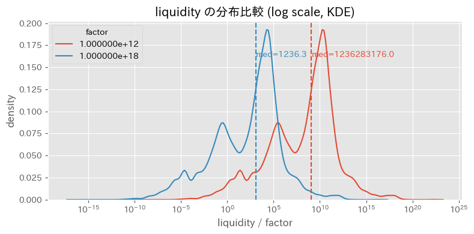

```python
# 文字列から数値型へ変換
raw_clean_with_pool["liquidity_numeric"] = pd.to_numeric(raw_clean_with_pool["liquidity"], errors="coerce")
raw_clean_with_pool["sqrt_price_numeric"] = pd.to_numeric(raw_clean_with_pool["sqrt_price"], errors="coerce")

# 元データ準備
liq = raw_clean_with_pool["liquidity_numeric"].dropna()
liq = liq[liq > 0]
spr = raw_clean_with_pool["sqrt_price_numeric"].dropna()
spr = spr[spr > 0]

factors = [1e12, 1e18]
colors = ["C0", "C1"]

plt.figure(figsize=(8, 4))
for f, c in zip(factors, colors):
    sns.kdeplot(liq / f, log_scale=True, label=f"{int(f):e}", color=c)
    q1, med, q3 = (liq / f).quantile([0.25, 0.5, 0.75])
    plt.axvline(med, color=c, ls="--")
    plt.text(med, plt.ylim()[1] * 0.8, f"med={med:.1f}", color=c)

plt.title("liquidity の分布比較 (log scale, KDE)")
plt.xlabel("liquidity / factor")
plt.ylabel("density")
plt.legend(title="factor")
plt.tight_layout()
plt.show()
```

上図について、

- **青線 (factor=1e18, 推奨)**：
  - 中央値はおよそ `1.2×10³`、分布の山も裾も適切に追えるレンジ
  - モデル学習前の対数変換・正規化との相性が良い
- **赤線 (factor=1e12)**：
  - 中央値はおよそ `1.2×10⁹`、非常に大きな値に寄ってしまい、
  - モデル入力後に他特徴量とのスケール差が目立ちやすい

1e18 でスケーリングすることで、

- 値のばらつきを十分に残しつつ
- 入力レンジが適度にコンパクト

#### スケーリング係数の選定

1e18 のみ「log 軸上で分布山が見やすく」「外れ値の裾も適度に残る」ため、スケーリング係数として `1e18` を採用します。

### スケーリング後の分布

```python
# 上記よりスケーリング係数を1e18として設定
estimated_factor = 1e18
```

```python
from scipy import stats

# スケーリング
raw_clean_with_pool["liquidity_scaled"] = raw_clean_with_pool["liquidity_numeric"] / estimated_factor
raw_clean_with_pool["sqrt_price_scaled"] = raw_clean_with_pool["sqrt_price_numeric"] / estimated_factor

desc = raw_clean_with_pool["liquidity_scaled"].agg(["mean", "median", "std"])
skew, kurt = (
    stats.skew(raw_clean_with_pool["liquidity_scaled"]),
    stats.kurtosis(raw_clean_with_pool["liquidity_scaled"]),
)
summary = {"mean": desc["mean"], "median": desc["median"], "std": desc["std"], "skewness": skew, "kurtosis": kurt}
summary
```

```
{'mean': 2937187388923.8823,
 'median': 1181.8018992220357,
 'std': 230229421939447.56,
 'skewness': 79.13947811600646,
 'kurtosis': 6279.520502306922}
```

```python
qs = raw_clean_with_pool["liquidity_scaled"].quantile([0.01, 0.05, 0.25, 0.5, 0.75, 0.95, 0.99])
qs
```

```
0.01    1.466118e-08
0.05    1.037473e-05
0.25    3.601585e-01
0.50    1.181802e+03
0.75    3.255444e+04
0.95    1.405415e+07
0.99    2.644503e+10
Name: liquidity_scaled, dtype: float64
```

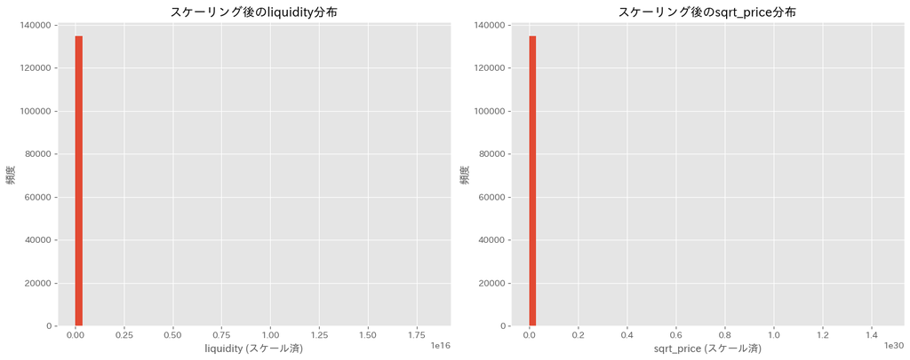

```python
# スケーリング後の分布を確認
plt.figure(figsize=(15, 6))

plt.subplot(1, 2, 1)
plt.hist(raw_clean_with_pool["liquidity_scaled"], bins=50)
plt.title("スケーリング後のliquidity分布")
plt.xlabel("liquidity (スケール済)")
plt.ylabel("頻度")

plt.subplot(1, 2, 2)
plt.hist(raw_clean_with_pool["sqrt_price_scaled"], bins=50)
plt.title("スケーリング後のsqrt_price分布")
plt.xlabel("sqrt_price (スケール済)")
plt.ylabel("頻度")

plt.tight_layout()
plt.show()
```

図より、

- **極端な右裾**
  - `liquidity_scaled` はほとんどの値が 0〜1×10¹⁶ に集中し、ごく一部の巨大な値（外れ値）が分布を引き延ばしている。
  - `sqrt_price_scaled` も同様に、低スケール領域に集中しつつ、非常に大きな値が存在する。
- **問題点**
  - このままではヒストグラム／モデル両方で外れ値の影響が過大になる。
  - 分布の偏りが大きいため、線形スケーリングのままでは相対的な違いが見えづらい。
- **次のステップ**
  1. **対数変換**（`np.log`）を適用し、分布の歪みを緩和する。
  2. 変換後のヒストグラムで再度分布を確認し、外れ値の影響が抑えられているかを評価する。

#### 対数変換に `np.log` を適用する理由

> ※もしゼロ値が残っている場合は `np.log1p`（`log(1+x)`）を使うことでゼロを安全に扱えますが、今回は事前に小さな正の値でクリップしているため、`np.log` 良いと考えています。

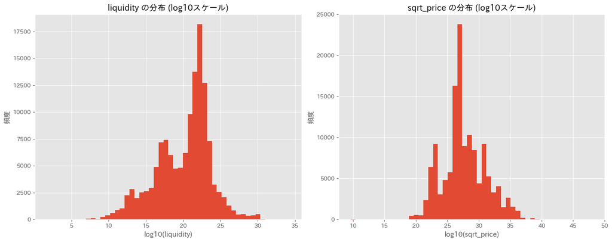

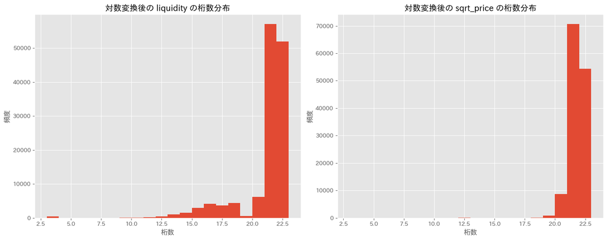

```python
# ヒストグラムで分布を確認（対数スケール）
plt.figure(figsize=(15, 6))

plt.subplot(1, 2, 1)
# null値や負値を除外して対数変換
valid_liquidity = raw_clean_with_pool["liquidity_numeric"].dropna()
valid_liquidity = valid_liquidity[valid_liquidity > 0]
plt.hist(np.log10(valid_liquidity), bins=50)
plt.title("liquidity の分布 (log10スケール)")
plt.xlabel("log10(liquidity)")
plt.ylabel("頻度")

plt.subplot(1, 2, 2)
# null値や負値を除外して対数変換
valid_sqrt_price = raw_clean_with_pool["sqrt_price_numeric"].dropna()
valid_sqrt_price = valid_sqrt_price[valid_sqrt_price > 0]
plt.hist(np.log10(valid_sqrt_price), bins=50)
plt.title("sqrt_price の分布 (log10スケール)")
plt.xlabel("log10(sqrt_price)")
plt.ylabel("頻度")

plt.tight_layout()
plt.show()

# 桁数の分布を確認（文字列長を使用）
raw_clean_with_pool["liquidity_digits"] = raw_clean_with_pool["liquidity"].astype(str).str.len()
raw_clean_with_pool["sqrt_price_digits"] = raw_clean_with_pool["sqrt_price"].astype(str).str.len()

plt.figure(figsize=(15, 6))

plt.subplot(1, 2, 1)
plt.hist(
    raw_clean_with_pool["liquidity_digits"],
    bins=range(min(raw_clean_with_pool["liquidity_digits"]), max(raw_clean_with_pool["liquidity_digits"]) + 2),
)
plt.title("対数変換後の liquidity の桁数分布")
plt.xlabel("桁数")
plt.ylabel("頻度")

plt.subplot(1, 2, 2)
plt.hist(
    raw_clean_with_pool["sqrt_price_digits"],
    bins=range(min(raw_clean_with_pool["sqrt_price_digits"]), max(raw_clean_with_pool["sqrt_price_digits"]) + 2),
)
plt.title("対数変換後の sqrt_price の桁数分布")
plt.xlabel("桁数")
plt.ylabel("頻度")

plt.tight_layout()
plt.show()
```

図より、

次に下記の手順で実際に対数変換 → 正規化を行います。

1. **小さな正値 (ε = 1e–10) でクリップ** → 0 以下の値を排除
2. `np.log` による対数変換 → `liquidity_log`, `sqrt_price_log`
3. Min–Max 正規化 → `[0,1]` 範囲にスケール（`liquidity_norm`, `sqrt_price_norm`）

この後のセルで、変換後の分布を再度確認します。

### Min-Max 正規化で[0,1]範囲に収める

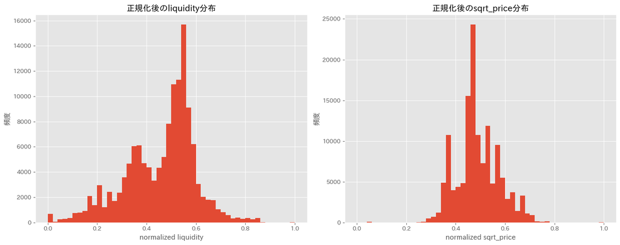

```python
# 偏りに対応するための対数変換
# 0またはそれ以下の値を小さな正の値に置き換えて対数変換可能にする
epsilon = 1e-10
raw_clean_with_pool["liquidity_log"] = np.log(raw_clean_with_pool["liquidity_scaled"].clip(lower=epsilon))
raw_clean_with_pool["sqrt_price_log"] = np.log(raw_clean_with_pool["sqrt_price_scaled"].clip(lower=epsilon))

# より均一な分布に調整
raw_clean_with_pool["liquidity_norm"] = (
    raw_clean_with_pool["liquidity_log"] - raw_clean_with_pool["liquidity_log"].min()
) / (raw_clean_with_pool["liquidity_log"].max() - raw_clean_with_pool["liquidity_log"].min())
raw_clean_with_pool["sqrt_price_norm"] = (
    raw_clean_with_pool["sqrt_price_log"] - raw_clean_with_pool["sqrt_price_log"].min()
) / (raw_clean_with_pool["sqrt_price_log"].max() - raw_clean_with_pool["sqrt_price_log"].min())

# 正規化後の分布確認
plt.figure(figsize=(15, 6))

plt.subplot(1, 2, 1)
plt.hist(raw_clean_with_pool["liquidity_norm"], bins=50)
plt.title("正規化後のliquidity分布")
plt.xlabel("normalized liquidity")
plt.ylabel("頻度")

plt.subplot(1, 2, 2)
plt.hist(raw_clean_with_pool["sqrt_price_norm"], bins=50)
plt.title("正規化後のsqrt_price分布")
plt.xlabel("normalized sqrt_price")
plt.ylabel("頻度")

plt.tight_layout()
plt.show()
```

図より、

- **0–1 に収まった**
  - 両変数とも Min–Max 正規化によって必ず [0,1] の範囲に収まり、モデル入力のスケールが統一できた。
- **特徴的なピーク**
  - **normalized liquidity**：およそ **0.4–0.6** の範囲に高さのピークが見られ、複数モード（プール種別や流動性帯ごとの違い）が残存している。
  - **normalized sqrt_price**：主に **0.4–0.5** に集中し、対数変換前の右裾の長い偏りが緩和されている。
- **分布のバランス向上**
  - 正規化後は極端な外れ値の影響が抑制され、全体的に平滑なヒストグラムになっているため、回帰や異常検知モデルなどで「値のスケール差による歪み」を軽減できる。
- **次のステップ**
  - 正規化後のデータを使って、Isolation Forest 等による異常検知モデルを学習し、“どのプールでいつ異常が起きるか” を定量的に捉えるフェーズに進みます。

### 巨大固定小数点整数の問題と対応策

Uniswap v3 における liquidity と sqrt_price 値は、ブロックチェーン上で精度を保持するために非常に大きな整数として表現されており、そのままでは分析や計算の支障となる可能性があります。

#### 原因

1. **固定小数点数形式の採用**  
   Solidity 等のスマートコントラクト言語では浮動小数点数をサポートしていないため、高精度計算のために値を大きな整数に変換して格納している。
2. **大きなスケーリング係数**  
   典型的には 10^18（ETH の Wei 単位と同じ）や 2^96 などの巨大な係数でスケールアップして格納。
3. **精度保持の要求**  
   AMM（自動マーケットメーカー）では価格計算の精度が重要なため、丸め誤差を最小化する特殊な数値表現が採用されている。

#### 問題の特性

これらの特性は、イーサリアムのスマートコントラクトにおける標準的な固定小数点表現と一致しています。

#### 影響

- 通常の DOUBLE 型へのキャストでは精度損失が発生し、値が不正確になる。
- 分析時に極端に大きい数値のため、相対比較や可視化が困難になる。
- 数値計算（特に乗算）時にオーバーフローのリスクがある。

#### 対応策

##### 1. スケーリング

- 分布分析により、liquidity は 20-23 桁、sqrt_price は 20-22 桁に集中していることを確認
- 対数スケール変換で実際の値の分布を検証し、10^18 が最適なスケーリング係数と判断
- DuckDB で DECIMAL(38,0) 型を使用し、POWER(10, 18) で除算することで精度を保持しつつスケーリング

##### 2. データ検証と異常値処理

- 変換前後の値の相関係数を確認し、情報損失がないことを検証
- スケーリング後も極端な値が存在する場合は、分位数に基づく異常値検出を実施
- 異常値フラグを追加し、モデルに情報として提供

#### 今後の改善検討事項

1. **追加での変換の検討**
   - 対数変換による正規化 `np.log1p(scaled_value)`
   - 分位点に基づく正規化 `(x - x.min()) / (x.max() - x.min())`
2. **プロトコル・プール特性に基づく調整**
   - Uniswap v3 と Sushiswap で異なるスケーリング係数の可能性
   - 特定のプールタイプ（安定コイン等）に対する特殊処理
3. **機械学習前処理パイプラインへの統合**
   - スケーリングと特徴量エンジニアリングの自動化
   - スケーリングハイパーパラメータのチューニング

### 参考資料

- [Uniswap v3 Core ホワイトペーパー](https://uniswap.org/whitepaper-v3.pdf)
- [Uniswap v3 Math in Solidity](https://github.com/Uniswap/v3-core/blob/main/contracts/libraries/FullMath.sol)

## 相関・多変量分析

- `volume_usd`, `tvl_usd`, `liquidity_scaled`, `sqrt_price_scaled` の相関ヒートマップ
- 主要指標ペアプロット（サンプル 5,000 件）

```python
corr = df[["volume_usd", "tvl_usd", "liquidity_scaled", "sqrt_price_scaled"]].corr()
sns.heatmap(corr, annot=True, fmt=".2f")
plt.show()
```

[output not shown]